# Tutorial on Bayesian Statistics: Replicating Sections of BDA3

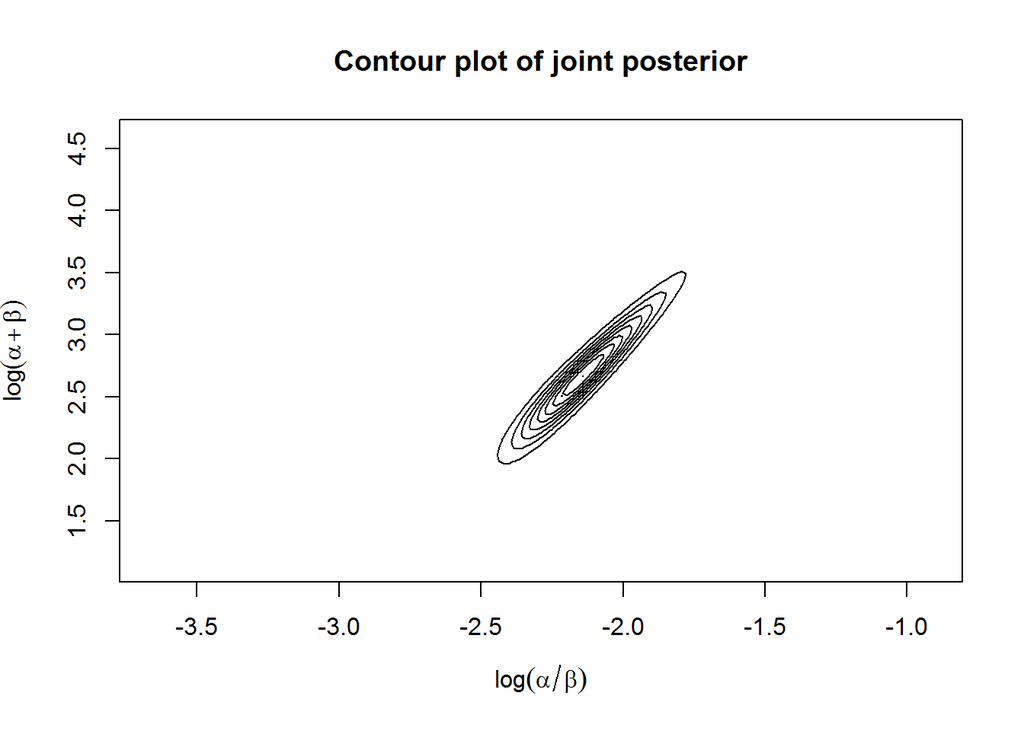

4.3. Recalculate the range of the grid such that includes all the density

```r v1 = seq(-2.3,-1.3,length.out =151) # The booksets the range of “v2” up to 5, but my gamma function calculator gives me trouble after 4.8 v2 = seq(1 , 4.5,length.out =151) beta = exp(v2)/(exp(v1)+1) alpha = exp(v2+v1)/(exp(v1)+1)

post.dens = outer(alpha,beta,function(x1,x2) log(rat.marg.post.phi(x1, x2)) ) post.dens = exp(post.dens - max(post.dens)) post.dens = post.dens/sum(post.dens)

contours <- seq(min(post.dens), max(post.dens) , length=10) contour(v1, v2, post.dens,levels=contours, xlab=expression(log(alpha/beta)), ylab=expression(log(alpha+beta)), xlim=c(min(v1),max(v1)) , ylim=c(min(v2),max(v2)), drawlabels=FALSE, main=“Contour plot of joint posterior”) ```

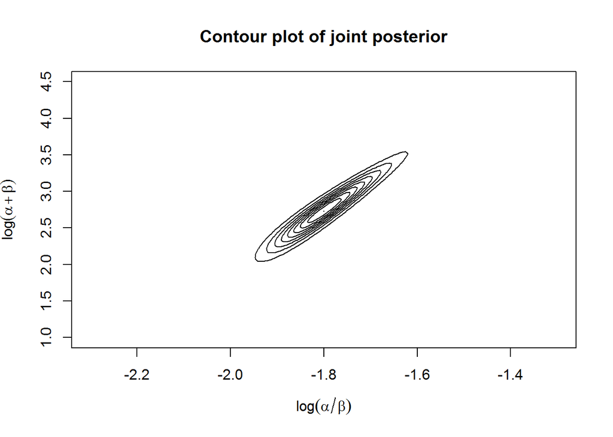

4.4. Draw samples $(\alpha^{s}, \beta^{s})$ from $p(\alpha,\beta|y)$ (finally!). Here we repeat the procedure used in section 3.(v) of this document.

```r samps = 1000 #Get density of log(alpha/beta|y) v1.dens = apply(post.dens ,1, sum) #Sample from it s.v1 = sample(v1,samps, replace=TRUE, prob = v1.dens)

#Select the colum of the joint density corresponding to a specific value of v1 (p(v2|v1)) cond.v2 = function(x) { post.dens[which(v1 == s.v1[x]),] } #Sample a value of v2 according the the conditional probatility above s.v2 = sapply(1:samps,function(x) sample(v2,1,replace=TRUE,prob=cond.v2(x)))

#Add a uniform random jitter centered at zero with with equal to the grid spacing. ##This will make the simulation draws more continuous. Plot the sampled values. grid.v1 = v1[2]-v1[1] grid.v2 = v2[2]-v2[1] s.v2 = s.v2 + runif(length(s.v2),-grid.v2/2,grid.v2/2) s.v1 = s.v1 + runif(length(s.v1),-grid.v1/2,grid.v1/2) plot(s.v1, s.v2, xlab=expression(log(alpha/beta)<sup>s), ylab=expression(log(alpha+beta)</sup>s), xlim=c(min(v1),max(v1)) , ylim=c(min(v2),max(v2)), main=“Scatter Plot of Sample Draws of log(alpha/beta) and log(alpha+beta)”) ```

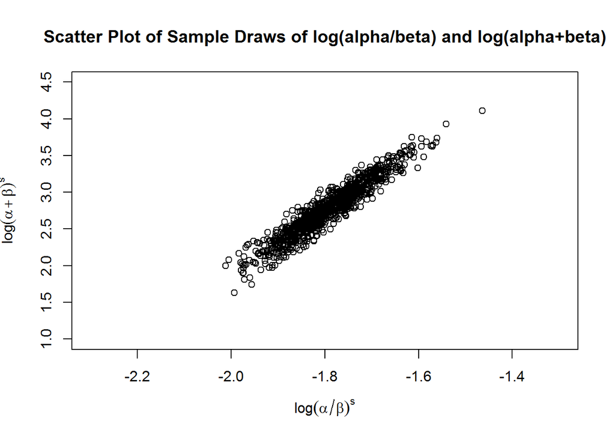

**Note:**this two figures do not match exactly their counterparts in the textbook (5.3a and 5.3b in BDA3), but so far I have not been able to detect my mistakes (the Jacobian doesn’t seem to be the problem, but feel free to double check). This is particularly strange as I can replicate the calculations of p112 where $E[\alpha|y] = 2.41$ and $E[\beta|y] = 14.13$.

4.5 By applying the inverse of the transformation we recover the marginal distribution of the original hyper-parameters.

5. For each draw of $\phi^{s}$, draw a sample of $\theta$ from $p(\theta|\phi^{s},y)$

`r s.beta = exp(s.v2)/(exp(s.v1)+1) s.alpha = exp(s.v2+s.v1)/(exp(s.v1)+1) theta.dist = sapply(1:71, function(x) rbeta(1000,s.alpha+y[x], s.beta + n[x] - y[x])) theta.dist = apply(theta.dist,2,sort) plot(0:450/1000,0:450/1000, type = "l", lty=1, xlab="Observed rate", ylab="95% CI and median of posterior") jitter.x = y/n + runif(length(y),-0.01,0.01) points(jitter.x,theta.dist[500,]) segments(jitter.x,theta.dist[25,], jitter.x,theta.dist[975,] ) title(main="Posterior Distribution of Tumor Rates for all 71 Experiments \n (Remember the goal? This is it!)") abline(h = mean(theta.dist), lty = 2) legend("bottomright",legend=c("Observed = Posterior","Overall Posterior Mean"),lty = c(1,2))`

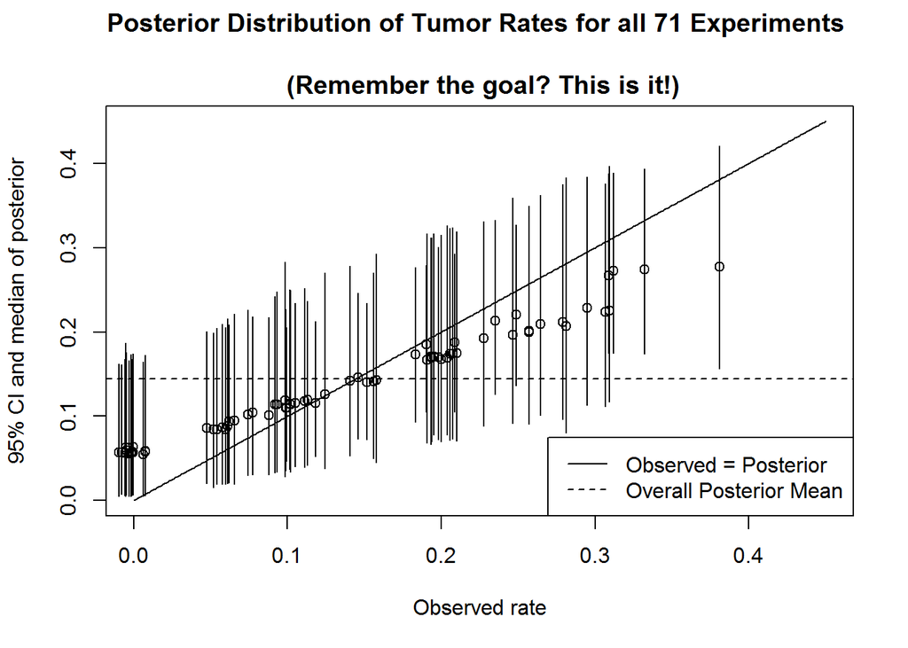

# 5 - Replicating section 5.5: Experiments in eight schools (normal model) [Without Stan]

```r #Data: school.id <- LETTERS[1:8] effect <- c(28,8,-3,7,-1,1,18,12) se.effect <- c(15,10,16,11,9,11,10,18)

pool.est <- sum(effect*se.effect<sup>-2)/sum(se.effect</sup>-2) pool.var <- sum(se.effect<sup>-2)</sup>-1 pool.ci <- c(-1.96,1.96)*pool.var^.5 + pool.est ```

The pooled estimated effect and variance are 7.69 and 16.58, with a 95% CI of [-0.3, 15.67].

*Posterior simulation under the hierarchical model* Using the identity: $\begin{aligned} p(\theta,\mu,\tau|y) = p(\tau|y)p(\mu|\tau,y)p(\theta|\mu,\tau,y) \end{aligned}$ And the results from BDA in equation 5.17, 5.20 and 5.21 we code the posteriors $p(\theta_{j} | \tau, \mu, y), p(\mu|\tau,y)$ and $p(\tau|y)$. **Important note:** for this excercise we could have follow *exactly* the same steps as the last excercise. Given some properties of the N-N model, we took a differente path and derive an analytic formula for $p(\mu|\tau,y)$ and $p(\tau|y)$ (instead of sampling from the join posterior density).

```r # Eqn 5.17 of BDA3 post.theta.j <- function(mu,tau,j) { ( effect[j] / ( se.effect[j]^2 ) + mu / ( tau^2 ) ) / ( 1 / ( se.effect[j]^2 ) + 1 / ( tau^2 ) ) }

post.v.theta.j <- function(tau,j) { 1 / ( 1 / ( se.effect[j]^2 ) + 1 / ( tau^2 ) ) }

# Eqn 5.20 of BDA3 post.mu.hat <- function(tau) { sum( effect * 1 / ( se.effect^2 +tau^2 ) ) / sum( 1 / ( se.effect^2 + tau^2 ) ) } post.v.mu <- function(tau) { ( sum( 1 / ( se.effect^2 +tau^2 ) ) )^-1 } # Eqn 5.21 of BDA3 marginal.tau <- function(tau) { hyper.prior(tau) *( post.v.mu(tau)^.5 )* prod( ( ( se.effect^2 + tau^2 )^(-.5) ) *exp( - ( ( effect - post.mu.hat( tau ) )^2 ) / ( 2* ( se.effect^2 + tau^2 ) ) ) ) } ```

Define a hyper-prior and draw 200 samples from each distribution (for all 8 schools).

```r samps <- 200

hyper.prior <- function(tau) 1 tau.grid <- seq(0.001,30, length=samps) pdf.tau <- sapply(tau.grid,function(x) marginal.tau(x)) pdf.tau <- pdf.tau/sum(pdf.tau)

plot(tau.grid,pdf.tau, type=“l”, main=“Figure 5.5 from BDA3”, xlab=expression(tau), ylab=“Density”) ```

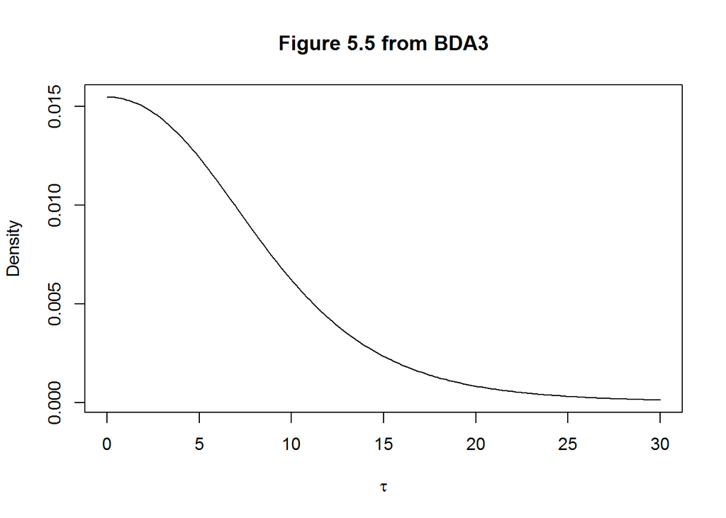

The sampling method in BDA3 suggest to apply the inverse method from the posterior of $\tau$. I don’t do this for two reasons: (i) I’m not sure the posterior has a closed for solution for its inverse, and (ii) given that I already have the density, I can directly draw from that distribution sampling using the `sample` command (which leads me to think that this command applies the inverse method).

`r # Sampling s.tau <- sample(tau.grid,samps,prob=pdf.tau, replace=TRUE) s.mu <- sapply(s.tau,function(x) rnorm(1,post.mu.hat(x),(post.v.mu(x))^0.5)) s.theta <- NULL for (j in 1:length(school.id)) { s.theta[[j]] <- sapply(1:samps, function(x) rnorm(1, post.theta.j(s.mu[x],s.tau[x],j), (post.v.theta.j(s.tau[x],j))^0.5 ) ) }`

**The following figures replicate the figures in pg 122 in BDA. Before doing the plots we need to ‘average over $\mu$’**

$\begin{aligned} E(\theta_{j}|\tau,y) &= E_{\mu}\left[E(\theta_{j}|\tau,y,\mu)|\tau,y\right] \nonumber \\ &= E_{\mu}\left[\frac{ \frac{1}{\sigma_{j}^{2}}y_{j} + \frac{1}{\tau^{2}}\mu }{\frac{1}{\sigma_{j}^{2}} + \frac{1}{\tau^{2} } }|\tau,y\right] = \frac{ \frac{1}{\sigma_{j}^{2}}y_{j} + \frac{1}{\tau^{2}}\hat{\mu} }{\frac{1}{\sigma_{j}^{2}} + \frac{1}{\tau^{2} } }\\ \nonumber \\ Var(\theta_{j}|\tau,y) &= E_{\mu}\left[Var(\theta_{j}|\tau,y,\mu)|\tau,y\right] + Var_{\mu}\left[E(\theta_{j}|\tau,y,\mu)|\tau,y\right] \nonumber \\ &= \frac{1}{\frac{1}{\sigma_{j}^{2}} + \frac{1}{\tau^{2} }} + V_{\mu}\left(\frac{\frac{1}{\tau^{2}}}{\frac{1}{\sigma_{j}^{2}} + \frac{1}{\tau^{2} }}\right) \end{aligned}$

Where $V_{\mu}$ and $\hat{\mu}$ correspond to the expressions defined in Eq 5.20 of BDA3. Below is the code and plot of both equations.

```r post.theta.j.no.mu <- function(tau,j) post.theta.j( post.mu.hat( tau ), tau, j ) post.se.theta.j.no.mu <- function(tau,j) sqrt( ( post.v.theta.j( tau, j ) ) * ( 1 + post.v.mu( tau ) * tau^(-2) ) )

plot( tau.grid, sapply(tau.grid, function(x) post.theta.j.no.mu(x,1) ), type=“l”, ylim=c(-5,30), xlab=“”, ylab=“”) title(main=“Figure 5.6 from BDA3”, xlab=expression(tau), ylab=“Estimated treatment effect”)

for (j in 2:8) { lines( tau.grid, sapply( tau.grid, function(x) post.theta.j.no.mu(x,j) ) ) } ```

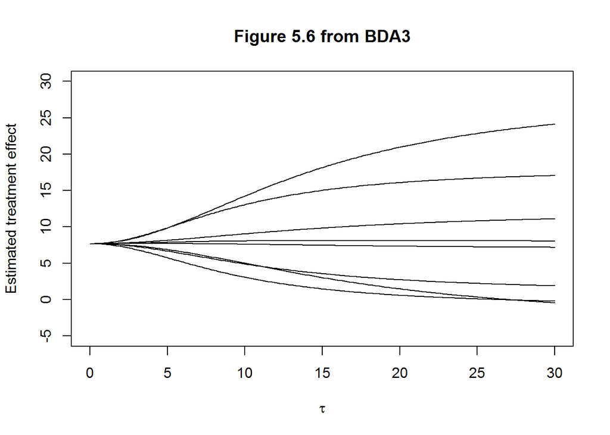

```r plot( tau.grid, sapply(tau.grid, function(x) post.se.theta.j.no.mu(x,1) ), type=“l”, ylim=c(0,20), xlab=“”, ylab=“”) title(main=“Figure 5.7 from BDA3”, xlab=expression(tau), ylab=“Posterior Standard Deviation”)

for (j in 2:8) { lines( tau.grid, sapply( tau.grid, function(x) post.se.theta.j.no.mu(x,j) ) ) } ```

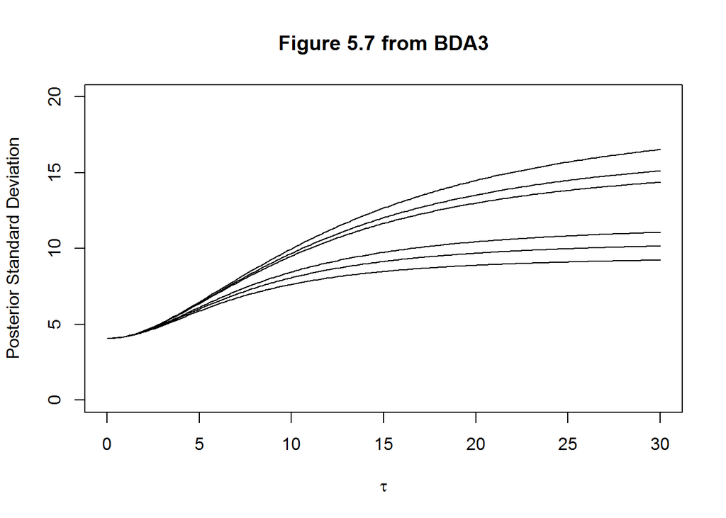

Now we can use the simulated $\theta_s$ to described the estimated effects in each school.

```r s.theta <- matrix(unlist(s.theta), ncol = 8, byrow = FALSE) s.theta.sort <- apply(s.theta, 2, sort) p <- t( apply( s.theta.sort, 2, function(x) { quantile( x, c( .025, .25, .5, .75, .975), type=1 ) } ) )

p <- round(p,3) knitr::kable(p, caption=“Table 5.3 from BDA3: Summary of 200 simulations of the treatment effects in the eight schools”) ```

Table: Table 5.3 from BDA3: Summary of 200 simulations of the treatment effects in the eight schools

2.5% 25% 50% 75% 97.5%

-0.959 5.126 8.799 14.701 31.639 -4.707 3.321 7.599 11.384 20.985 -15.041 2.191 6.602 10.440 17.380 -9.037 2.942 6.870 11.321 20.173 -8.086 2.217 6.210 9.562 18.036 -6.893 2.292 6.263 10.170 19.596 -1.023 5.646 9.295 14.107 29.198 -7.684 4.477 7.525 12.355 24.877

| School |  |  |  |  |  |
| --- | --- | --- | --- | --- | --- |
|  | 2.5% | 25% | median | 75% | 97.5% |
| A | -0.959 | 5.126 | 8.799 | 14.701 | 31.639 |
| B | -4.707 | 3.321 | 7.599 | 11.384 | 20.985 |
| C | -15.041 | 2.191 | 6.602 | 10.44 | 17.38 |
| D | -9.037 | 2.942 | 6.87 | 11.321 | 20.173 |
| E | -8.086 | 2.217 | 6.21 | 9.562 | 18.036 |
| F | -6.893 | 2.292 | 6.263 | 10.17 | 19.596 |
| G | -1.023 | 5.646 | 9.295 | 14.107 | 29.198 |
| H | -7.684 | 4.477 | 7.525 | 12.355 | 24.877 |

Here we reproduce figure 5.8 (with the same problems as above)

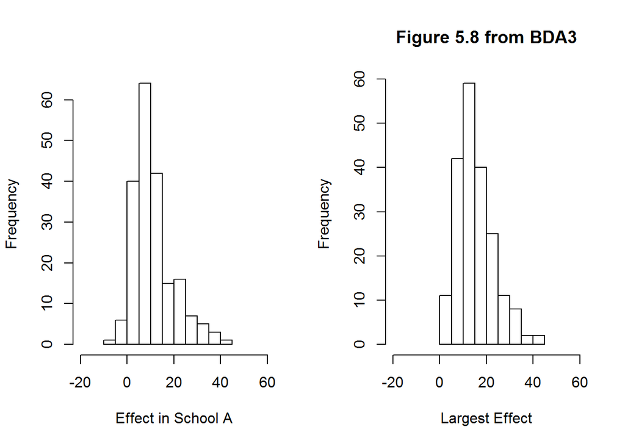

```r
par(mfrow=c(1,2))
domain           <- c(-20,60)
hist(s.theta[,1], breaks=10, xlab="Effect in School A", main="", xlim=domain)
hist(apply(s.theta,1,max), breaks=10, xlab="Largest Effect", main="", xlim=domain)
title(main="Figure 5.8 from BDA3")
```

This last figure (“largest effect”) is a good example of one the main advantage of a fully Bayesian hierarchical model: once we have correctly simulated the posterior, we can test all kinds of complicated hypothesis.